# Final Exam Dataset #4: Personality

# Quick high-level visualization of the data (in R)

```python
%load_ext rpy2.ipython
```

```python
%%R

not.installed <- function(pkg) !is.element(pkg, installed.packages()[,1])

if (not.installed("tabplot")) install.packages("tabplot")
library(tabplot)

if (not.installed("corrplot")) install.packages("corrplot")
library(corrplot)
```

```python
%%R

Personality = read.csv("Personality.csv", header=TRUE)

random_subset = sample(1:nrow(Personality), 300)
#  sample since the table is large

p = ncol(Personality)

ScoreValues = Personality[ random_subset, (p-15):p ]  # last 16 columns
```

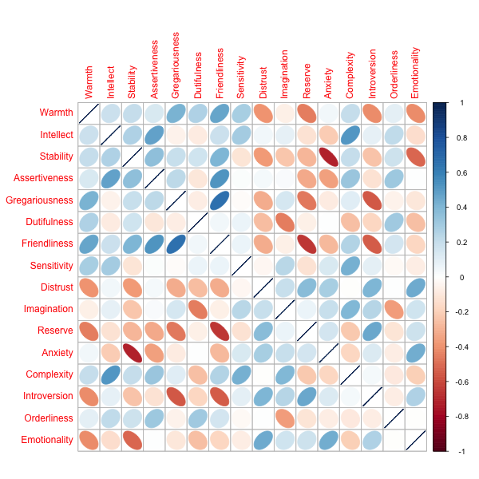

```python
%%R -w 600 -h 600

corrplot( cor(ScoreValues), method="ellipse" )
```

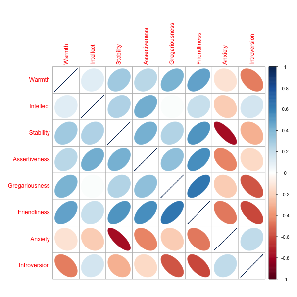

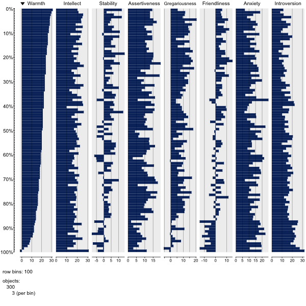

```python
%%R -w 600 -h 600

ScoreSubset1 = subset( ScoreValues,
                 select = c("Warmth","Intellect",
                            "Stability","Assertiveness",
                            "Gregariousness","Friendliness",
                            "Anxiety","Introversion"))

corrplot(cor(ScoreSubset1), method="ellipse")

tableplot(ScoreSubset1)
```

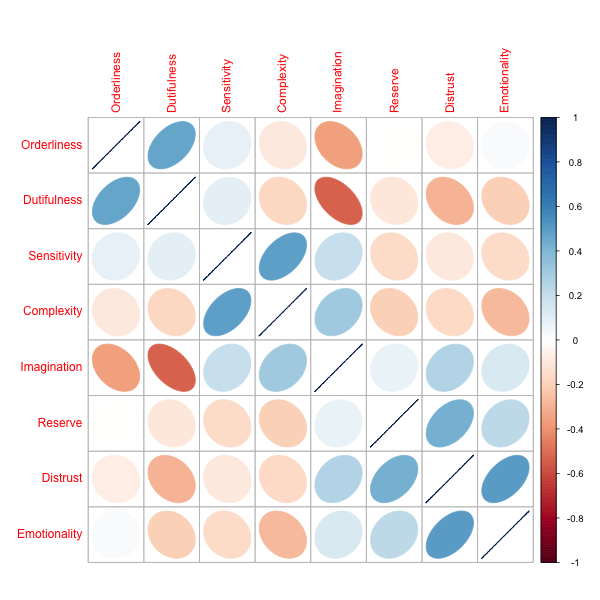

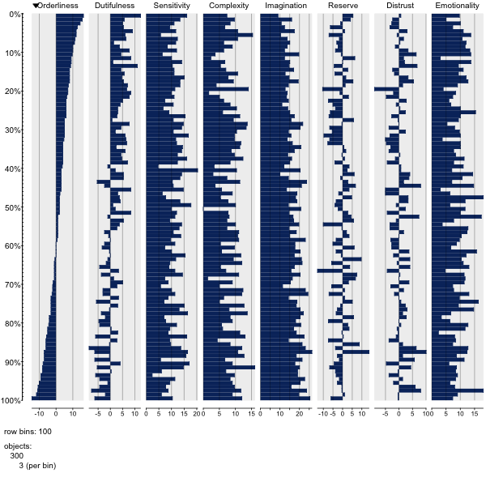

```python
%%R -w 600 -h 600

ScoreSubset2 = subset( ScoreValues,
                 select = c("Orderliness","Dutifulness",
                            "Sensitivity","Complexity","Imagination",
                            "Reserve","Distrust","Emotionality"))

corrplot(cor(ScoreSubset2), method="ellipse")

tableplot(ScoreSubset2)
```